# DS6306-CaseStudy2

Shelby Provost

8/4/2021

## Executive Summary

DDSAnalytics would like to predict employee turnover for Frito Lay employees. Given an existing data set with 32 potential predictor variables for attrition, a brief analysis was conducted. Interesting insights, job specific trends, a model for predicting attrition, and a model for predicting salary were obtained from this data.

## Exploring the data

```
##  No Yes
## 730 140
```

```
## [1] 0.8390805
```

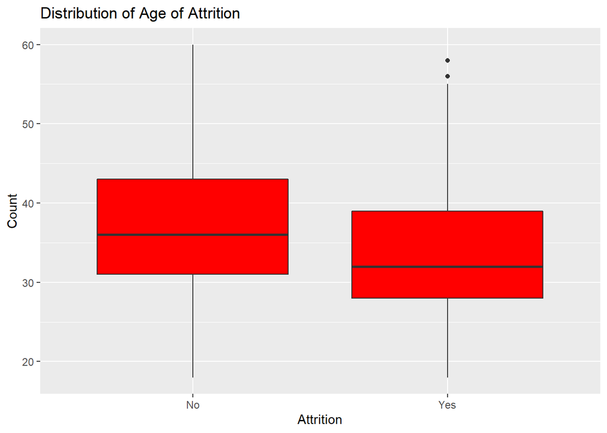

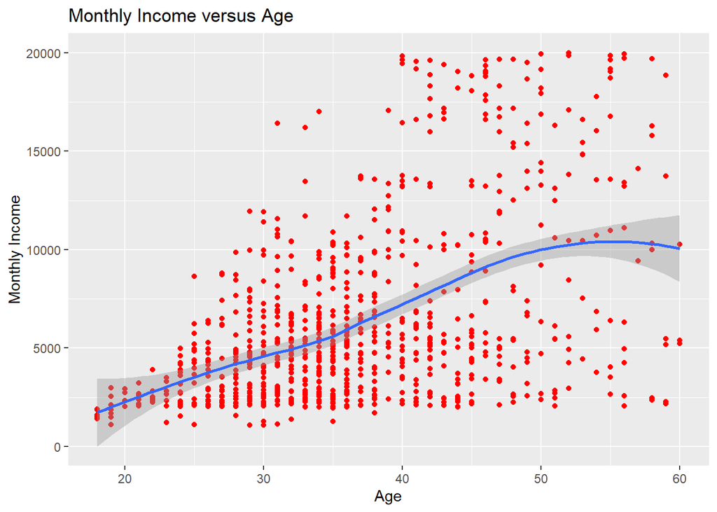

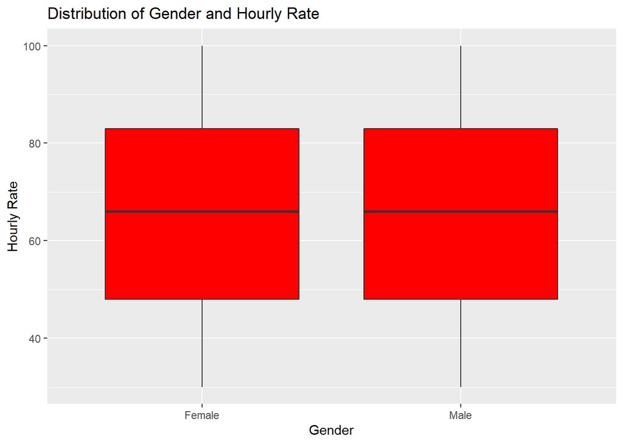

## Exploring Job Specific Trends

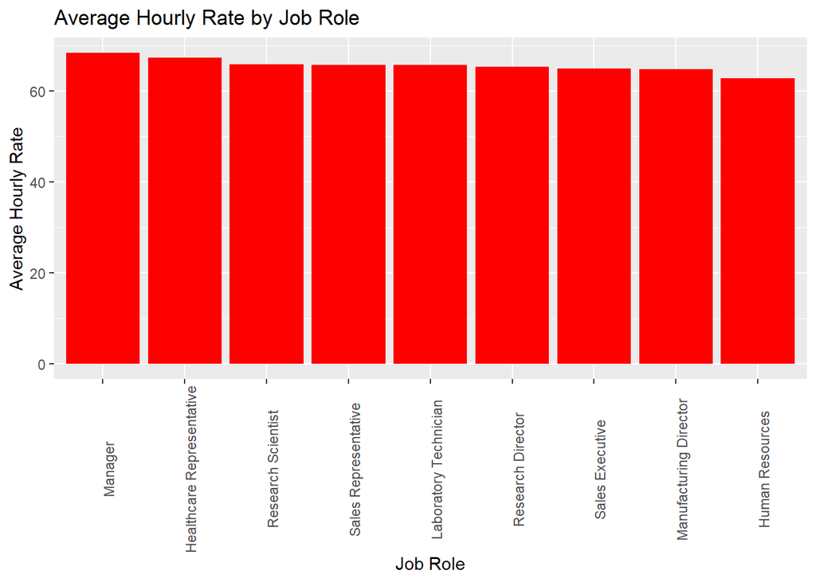

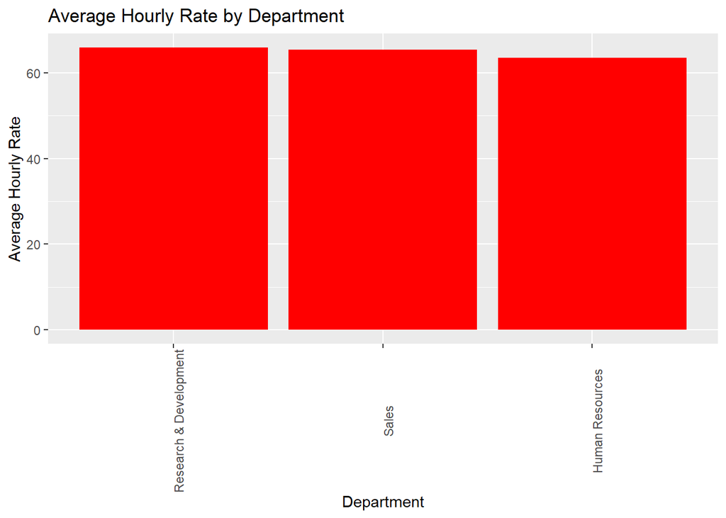

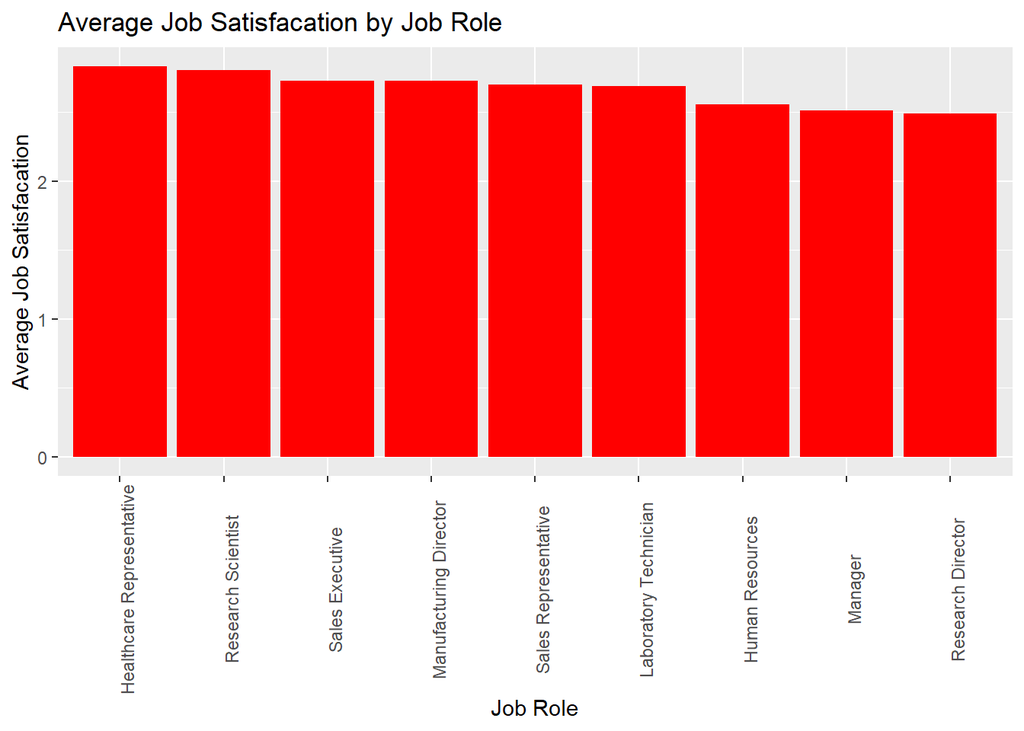

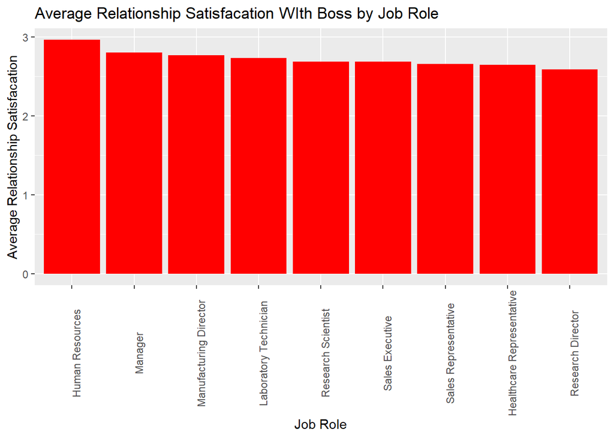

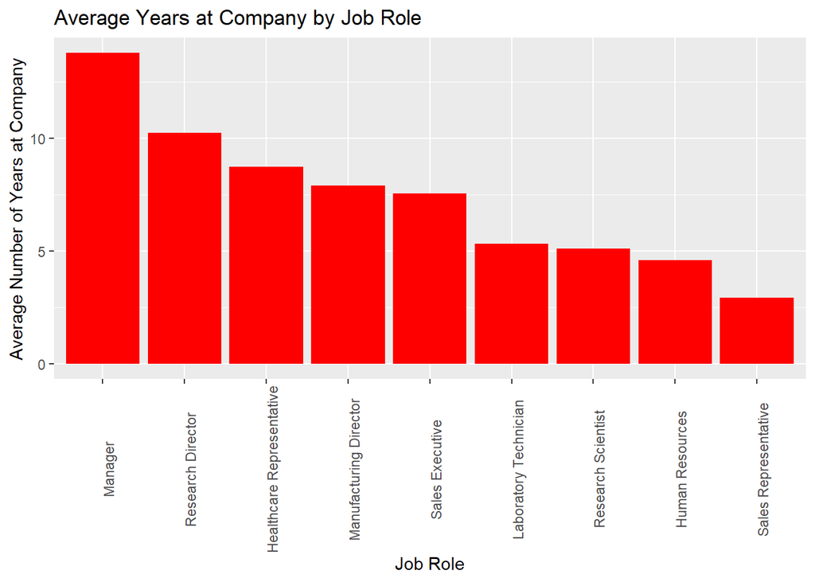

```
##                     JobRole countTot NumAttrition NumRetention PercentAttrition
## 1 Healthcare Representative       76            8           68        10.526316
## 2           Human Resources       27            6           21        22.222222
## 3     Laboratory Technician      153           30          123        19.607843
## 4                   Manager       51            4           47         7.843137
## 5    Manufacturing Director       87            2           85         2.298851
## 6         Research Director       51            1           50         1.960784
## 7        Research Scientist      172           32          140        18.604651
## 8           Sales Executive      200           33          167        16.500000
## 9      Sales Representative       53           24           29        45.283019
##   PercentRetention
## 1         89.47368
## 2         77.77778
## 3         80.39216
## 4         92.15686
## 5         97.70115
## 6         98.03922
## 7         81.39535
## 8         83.50000
## 9         54.71698
```

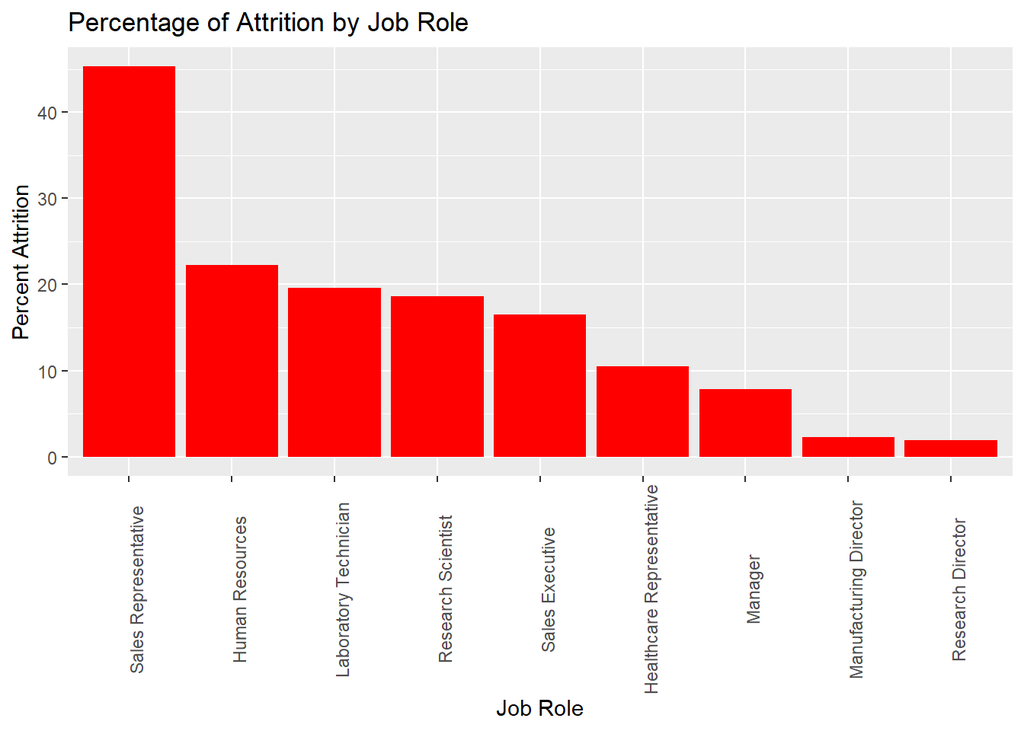

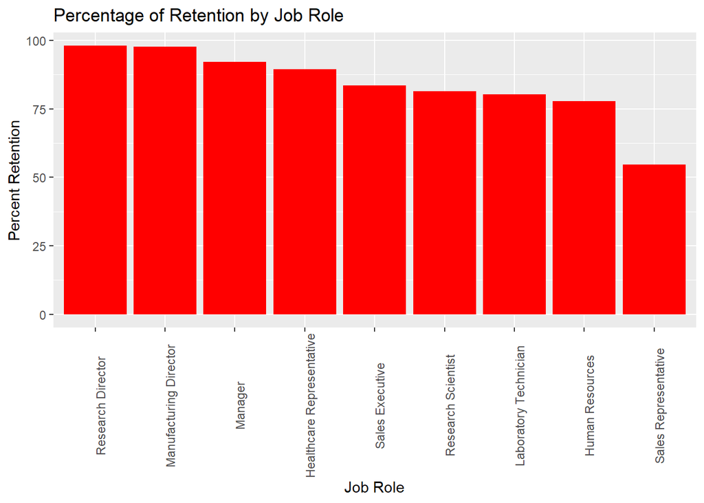

Exploring job role specific trends, we find that Managers have the highest average hourly rate while human resources have the lowest. Health Care representatives have the highest average job satisfaction while research directors have the lowest. Human resources have the highest average relationship satisfaction with their managers while research directors have the lowest. Managers have the highest average number of years with the company while sales representatives have the lowest. Which is unsurprising that we find that sales representatives have the highest attrition rate. Research directors have the highest retention rate which may seem odd as we found that research directors have the lowest average job satisfaction and the lowest average relationship satisfaction with their managers. It is also interesting that we found that human resource employees have the highest relationship satisfaction with their managers as they also have the lowest average hourly rate. Nonetheless, these relationships show insights into the reasons employees may choose to stay with the company or leave.

## Creating the Best Models

```
## Confusion Matrix and Statistics
##
##
##        No Yes
##   No  640  51
##   Yes  90  89
##
##                Accuracy : 0.8379
##                  95% CI : (0.8117, 0.8618)
##     No Information Rate : 0.8391
##     P-Value [Acc > NIR] : 0.559069
##
##                   Kappa : 0.4606
##
##  Mcnemar's Test P-Value : 0.001373
##
##             Sensitivity : 0.8767
##             Specificity : 0.6357
##          Pos Pred Value : 0.9262
##          Neg Pred Value : 0.4972
##              Prevalence : 0.8391
##          Detection Rate : 0.7356
##    Detection Prevalence : 0.7943
##       Balanced Accuracy : 0.7562
##
##        'Positive' Class : No
##
```

```
## Confusion Matrix and Statistics
##
##
##        No Yes
##   No  638  52
##   Yes  92  88
##
##                Accuracy : 0.8345
##                  95% CI : (0.8081, 0.8586)
##     No Information Rate : 0.8391
##     P-Value [Acc > NIR] : 0.664134
##
##                   Kappa : 0.4505
##
##  Mcnemar's Test P-Value : 0.001154
##
##             Sensitivity : 0.8740
##             Specificity : 0.6286
##          Pos Pred Value : 0.9246
##          Neg Pred Value : 0.4889
##              Prevalence : 0.8391
##          Detection Rate : 0.7333
##    Detection Prevalence : 0.7931
##       Balanced Accuracy : 0.7513
##
##        'Positive' Class : No
##
```

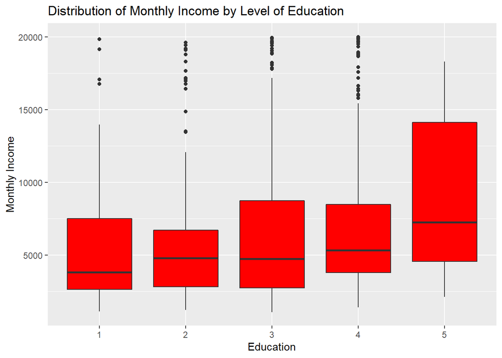

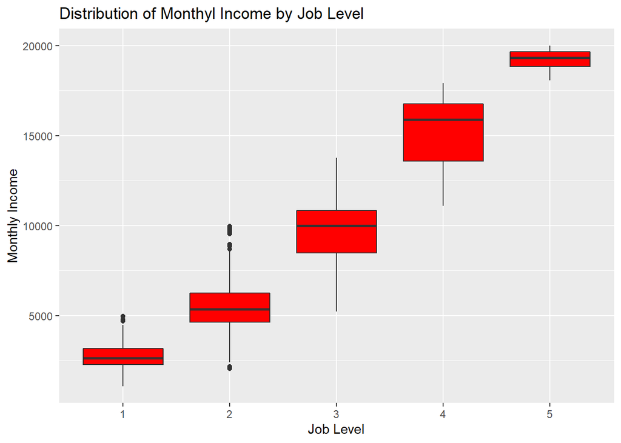

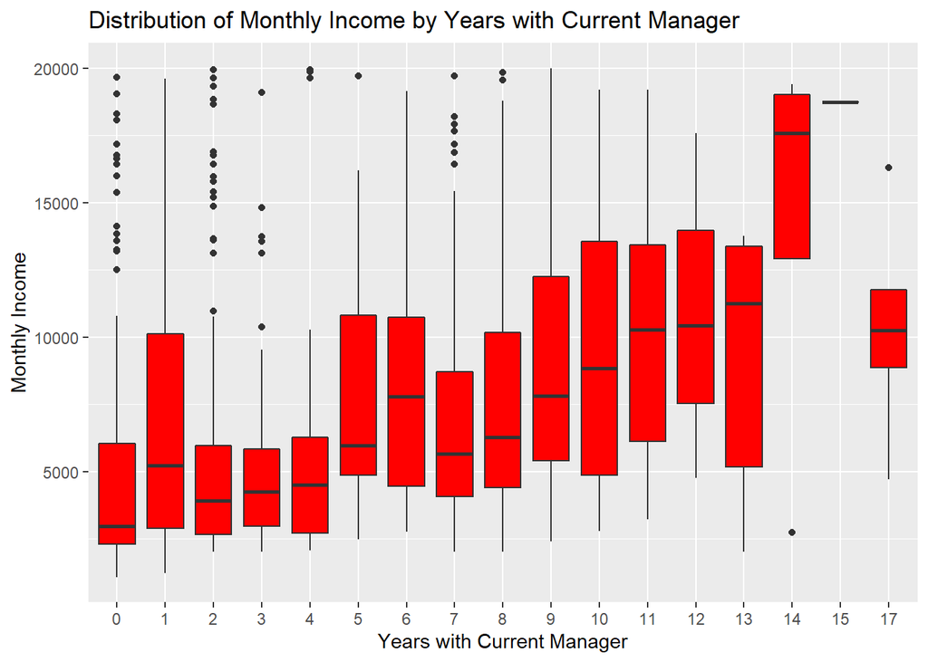

```
##
## Call:
## lm(formula = MonthlyIncome ~ Education + JobLevel + YearsWithCurrManager,
##     data = CaseStudy2.data)
##
## Residuals:
##     Min      1Q  Median      3Q     Max
## -5008.8  -933.4    63.8   712.0  3777.3
##
## Coefficients:
##                      Estimate Std. Error t value Pr(>|t|)
## (Intercept)          -1791.10     162.25 -11.039   <2e-16 ***
## Education               18.35      47.24   0.389   0.6977
## JobLevel              4048.07      47.47  85.283   <2e-16 ***
## YearsWithCurrManager   -30.49      14.41  -2.116   0.0346 *
## ---
## Signif. codes:  0 '***' 0.001 '**' 0.01 '*' 0.05 '.' 0.1 ' ' 1
##
## Residual standard error: 1411 on 866 degrees of freedom
## Multiple R-squared:  0.9061, Adjusted R-squared:  0.9058
## F-statistic:  2786 on 3 and 866 DF,  p-value: < 2.2e-16
```

## YouTube Presentation Link

[YouTube Presentation](https://youtu.be/zBg-wziVkCs)